# Import Required Packages

```python
import numpy as np
import pandas as pd
import pygeostat as gs
import matplotlib.pyplot as plt
import matplotlib.cm as cm
from mpl_toolkits.axes_grid1 import make_axes_locatable
import subprocess as sp
%pylab inline --no-import-all
from subprocess import check_output
import tensorflow as tf
from tensorflow.python import debug as tf_debug
import os
from sklearn.preprocessing import MinMaxScaler
from sklearn.model_selection import train_test_split
from sklearn.preprocessing import LabelEncoder
from sklearn.metrics import accuracy_score
from sklearn.cluster import KMeans
from sklearn import preprocessing
import scipy.spatial as scs
import scipy as sc
import math
from scipy.spatial import distance
from sklearn.metrics import mean_squared_error
import time
from sklearn.metrics import r2_score
from random import randrange
from IPython.display import clear_output
```

# Import Grid Definition

This is a 2D grid definition to keep the problem simple of illustration purposes

```python
griddef = gs.GridDef(gridfl='griddef.txt')
griddef
```

```
Pygeostat GridDef:
50 5.0 10.0
50 5.0 10.0
1 0.5 1.0
```

# Generate a Dataset

## Set Variogram Used To Simulate an Unconditional Realization

In this section we will be generating a sample data set used for machine learning. The first step will be to define a variogram to use to simulate an unconditional realization. Testing new techniques on simulated data provides a unique opportunity to have a direct comparison between the truth and the estimation.

```python
varg = ("1    0.01                   -nst, nugget effect\n\
3    0.99    135   45   0.0    -it,cc,azm,dip,tilt (ang1,ang2,ang3)\n\
        100    100    150    -a_hmax, a_hmin, a_vert (ranges)")

print(varg)
```

```
1    0.01                   -nst, nugget effect
3    0.99    135   45   0.0    -it,cc,azm,dip,tilt (ang1,ang2,ang3)
        100    100    150    -a_hmax, a_hmin, a_vert (ranges)
```

## Simulate Dataset

In the cell below a 2D unconditional realization will be generated with the variogram defined above

```python
sgsimpar = '''                  Parameters for SGSIM
                  ********************

START OF PARAMETERS:
cluster.dat           -file with data
1  2  3  4  0  0              -  columns for X,Y,Z,vr,wt,sec.var.
-1.0       1.0e21             -  trimming limits
0                             -transform the data (0=no, 1=yes)
sgsim.trn                     -  file for output trans table
0                             -  consider ref. dist (0=no, 1=yes)
histsmth.out                  -  file with ref. dist distribution
1  2                          -  columns for vr and wt
0.0    15.0                   -  zmin,zmax(tail extrapolation)
1       0.0                   -  lower tail option, parameter
1      15.0                   -  upper tail option, parameter
1                             -debugging level: 0,1,2,3
sgsim.dbg                     -file for debugging output
sgsim.out                     -file for simulation output
1                             -number of realizations to generate
{grid}
69069                         -random number seed
0     8                       -min and max original data for sim
48                            -number of simulated nodes to use
1                             -assign data to nodes (0=no, 1=yes)
1     3                       -multiple grid search (0=no, 1=yes),num
0                             -maximum data per octant (0=not used)
175  175.0  150.0              -maximum search radii (hmax,hmin,vert)
135.0  45.0   0.0              -angles for search ellipsoid
51    51    11                -size of covariance lookup table
0     0.60   1.0              -ktype: 0=SK,1=OK,2=LVM,3=EXDR,4=COLC
../data/ydata.dat             -  file with LVM, EXDR, or COLC variable
4                             -  column for secondary variable
{varg}

'''
sgsim= gs.Program(program='sgsim',parfile='sgsim.par')
sgsim.run(parstr=sgsimpar.format(varg = varg,
                                 grid = griddef
                                ))
```

```
Calling:  ['sgsim', 'sgsim.par']

 SGSIM Version: 4.000

  data file = cluster.dat
  input columns =            1           2           3           4           0
           0
  trimming limits =   -1.000000      1.0000000E+21
  transformation flag =            0
  transformation file = sgsim.trn
  consider smoothed distribution (1=yes) =            0
  file with smoothed distribution = histsmth.out
  columns =            1           2
  data limits (tails) =   0.0000000E+00   15.00000
  lower tail =            1  0.0000000E+00
  upper tail =            1   15.00000
  debugging level =            1
  debugging file = sgsim.dbg
  output file sgsim.out
  number of realizations =            1
  X grid specification =           50   5.000000       10.00000
  Y grid specification =           50   5.000000       10.00000
  Z grid specification =            1  0.5000000       1.000000
  random number seed =        69069
  min and max data =            0           8
  maximum previous nodes =           48
  two-part search flag =            1
  multiple grid search flag =            1           3
  number of octants =            0
  search radii =    175.0000       175.0000       150.0000
  search anisotropy angles =    135.0000       45.00000      0.0000000E+00
  Automatically calculating max covariance table...
  -  size needed for covariance lookup:    16   16    0
  kriging type =           51
 Old sgsim parameter file detected - reading again
  kriging type =            0
  secondary model file = ../data/ydata.dat
  column in secondary model file =            4
  nst, c0 =            1  9.9999998E-03
  it,cc,ang[1,2,3];            3  0.9900000       135.0000       45.00000
```

[output cut: 19 more lines]

```
   currently on node       750
   currently on node      1000
   currently on node      1250
   currently on node      1500
   currently on node      1750
   currently on node      2000
   currently on node      2250
   currently on node      2500

 Realization   1: number   =     2500
                  mean     =       0.1086 (close to 0.0?)
                  variance =       0.8108 (close to gammabar(V,V)? approx. 1.0)


 SGSIM Version: 4.000 Finished
```

### Read in the Simulated Dataset

```python
sgsimfl = gs.DataFile(flname='sgsim.out', griddef = griddef,
                       readfl=True)
print(sgsimfl.head())
```

```
      value
0 -1.514309
1 -1.496370
2 -1.095550
3 -1.116959
4 -0.983201
```

### Plot the Simulated Dataset

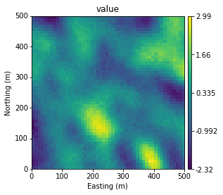

```python
gs.pixelplt(sgsimfl,griddef,orient='xy')
```

## Add coordinates to the Simulated Dataset to Be Used Later

```python
addcoordpar = '''                  Parameters for ADDCOORD
                  ***********************

START OF PARAMETERS:
{datafl}                         -file with data
addcoord.out                      -file for output
1                                 -realization number
{grid}
3 3 6                            -decimals for x, y, z (-1=exclude)
'''
addcoord= gs.Program(program='addcoord',parfile='addcoord.par')
addcoord.run(parstr=addcoordpar.format(datafl=sgsimfl.flname
                                ,grid = griddef
                                ))
```

```
Calling:  ['addcoord', 'addcoord.par']

 ADDCOORD VERSION: 4.1.0

 Data File = sgsim.out
 Output File = addcoord.out
 Realization number =            1
 X grid size =           50   5.00000000000000        10.0000000000000
 Y grid size =           50   5.00000000000000        10.0000000000000
 Z grid size =            1  0.500000000000000        1.00000000000000
 decimals =            3           3           6

 Format: (f07.03,x,f07.03,x,f07.06,x,a)

 ADDCOORD: 4.1.0 Finished
```

### Read in Simulation with Coordinates

```python
datafl = gs.DataFile(flname = 'addcoord.out',x='X',y='Y',z='Z', griddef=griddef,
readfl=True)
print(datafl.data.head())
```

```
      X    Y    Z     value
0   5.0  5.0  0.5 -1.514309
1  15.0  5.0  0.5 -1.496370
2  25.0  5.0  0.5 -1.095550
3  35.0  5.0  0.5 -1.116959
4  45.0  5.0  0.5 -0.983201
```

I like to re-plot the simulated data to help ensure nothing weird has gone on

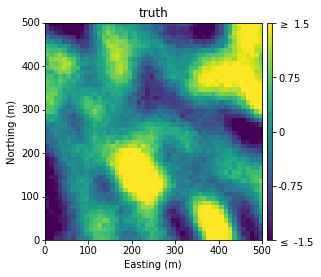

```python
gs.pixelplt(sgsimfl,griddef,title = 'truth',vlim = (-1.5,1.5))
```

## Sample The Simulated Drill

The program below is designed to sample a gridded data set either by drill holes spacing or randomly sample the grid

```python
gsamplepar = '''       Parameters for gsample V2.000
     *********************************

START OF PARAMETERS:
1                            - Number of files to sample
{datafl}            - File with first grid
1  {varcol1}                        - Number of variables and columns
1                            - Realization to sample
{griddef}
0                            - Sampling spacing option (0=regular, 1=random)
25  25                       -  If 0, spacing in X, Y
20  20                     -  If 0, collar of the first sample, X and Y (inside sampling grid)
80  69069                    -  If 1, number of drill holes and seed number
0  90                        - Azimuth and dip
0.5                            - Sample spacing downhole
1                          - Starting drill hole ID for new drills
2                            - Number of decimal places (coordinates precision, up to 6)
0   495                       - Sampling grid: xmin, xmax
0   495                       -                ymin, ymax
0   1                       -                zmin, zmax
dhs.out        - Output file with new drill holes
0                            - Output keyout file? (0=no, 1=yes)
0                            -  If keyout (0=input grid inside sampling grid, 1=input blocks with assays)
keyout.out         - Keyout file
'''
gsample= gs.Program(program='gsample',parfile='gsample.par')
gsample.run(parstr=gsamplepar.format(datafl=datafl.flname,
                                       varcol1=datafl.gscol('value'),
                                         griddef=griddef
                                      ))
```

```
Calling:  ['gsample', 'gsample.par']

GSAMPLE Version: 1.000

PARAMETER FILE                  = gsample.par
-----------------------------------------------------------------------------

INPUT PARAMETERS

Number of grids to sample       =   1
Total number of variables       =   1

Data file  1                    =
addcoord.out
Variable columns                =   4

Sample realization number       =   1

Input grid
Input grid in X                 =   50        5.00   10.00
Input grid in Y                 =   50        5.00   10.00
Input grid in Z                 =    1        0.50    1.00

Sample option                   =   0

Consider regular spacing


Spacing in X                    =    25.0
Spacing in Y                    =    25.0

Collar in X                     =    20.0
Collar in Y                     =    20.0

Azimuth                         =    0.00
Dip                             =    90.0

Sample distance downhole        =   0.500

Starting new drills with ID     =      1
```

[output cut: 24 more lines]

```

-----------------------------------------------------------------------------

Allocating memory

Finding block indices

Sampling from grid

Number of drill holes successfully created =  361
-----------------------------------------------------------------------------

END

Total execution time 0.020 seconds.
```

### Import the Sampled Drill Holes

```python
dataflpoints = gs.DataFile(flname='dhs.out', x='X',y='Y',z='Z', griddef = griddef,
                       readfl=True)
dataflpoints.describe()
```

|  | Drill ID | MD | Block ID | value |
| --- | --- | --- | --- | --- |
| count | 722.000000 | 722.000000 | 722.000000 | 722.000000 |
| mean | 181.000000 | 0.250000 | 1238.421053 | 0.136465 |
| std | 104.283567 | 0.250173 | 685.378723 | 0.871761 |
| min | 1.000000 | 0.000000 | 103.000000 | -1.931300 |
| 25% | 91.000000 | 0.000000 | 638.000000 | -0.427700 |
| 50% | 181.000000 | 0.250000 | 1225.000000 | 0.068100 |
| 75% | 271.000000 | 0.500000 | 1863.000000 | 0.601800 |
| max | 361.000000 | 0.500000 | 2398.000000 | 2.911800 |

Again it is useful to plot the drill holes and see what they look like

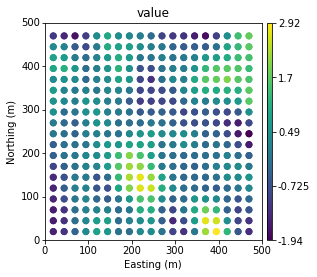

```python
gs.locmap(dataflpoints,var = 'value',orient='xy')
```

```python
print('Here I am removing columns that are not necessary to make the data set easier to work with')
datasamplefl = pd.DataFrame(dataflpoints.data, dtype = np.float32)
del datasamplefl['Drill ID']
del datasamplefl['MD']
del datasamplefl['Block ID']
datasamplefl['Z'] = datasamplefl['Z']
datasamplefl.drop_duplicates('value')
```

```
Here I am removing columns that are not necessary to make the data set easier to work with
```

|  | X | Y | Z | value |
| --- | --- | --- | --- | --- |
| 0 | 20.0 | 20.0 | 1.0 | -1.4885 |
| 2 | 45.0 | 20.0 | 1.0 | -1.2157 |
| 4 | 70.0 | 20.0 | 1.0 | -0.3973 |
| 6 | 95.0 | 20.0 | 1.0 | 0.3458 |
| 8 | 120.0 | 20.0 | 1.0 | 0.8231 |
| 10 | 145.0 | 20.0 | 1.0 | 0.6026 |
| 12 | 170.0 | 20.0 | 1.0 | -0.1281 |
| 14 | 195.0 | 20.0 | 1.0 | -0.1794 |
| 16 | 220.0 | 20.0 | 1.0 | 0.3482 |
| 18 | 245.0 | 20.0 | 1.0 | 0.3846 |
| 20 | 270.0 | 20.0 | 1.0 | -0.0652 |
| 22 | 295.0 | 20.0 | 1.0 | -0.9595 |
| 24 | 320.0 | 20.0 | 1.0 | -1.2509 |
| 26 | 345.0 | 20.0 | 1.0 | -0.0172 |
| 28 | 370.0 | 20.0 | 1.0 | 2.2261 |
| 30 | 395.0 | 20.0 | 1.0 | 2.9118 |
| 32 | 420.0 | 20.0 | 1.0 | 1.2570 |
| 34 | 445.0 | 20.0 | 1.0 | -0.6249 |
| 36 | 470.0 | 20.0 | 1.0 | -1.3088 |
| 38 | 20.0 | 45.0 | 1.0 | -1.5736 |
| 40 | 45.0 | 45.0 | 1.0 | -1.2523 |
| 42 | 70.0 | 45.0 | 1.0 | -0.1830 |
| 44 | 95.0 | 45.0 | 1.0 | 0.2923 |
| 46 | 120.0 | 45.0 | 1.0 | 0.7342 |
| 48 | 145.0 | 45.0 | 1.0 | 0.7782 |
| 50 | 170.0 | 45.0 | 1.0 | -0.2147 |
| 52 | 195.0 | 45.0 | 1.0 | 0.1865 |
| 54 | 220.0 | 45.0 | 1.0 | 0.4281 |
| 56 | 245.0 | 45.0 | 1.0 | 0.6109 |
| 58 | 270.0 | 45.0 | 1.0 | -0.4787 |
| ... | ... | ... | ... | ... |
| 662 | 220.0 | 445.0 | 1.0 | 0.4360 |
| 664 | 245.0 | 445.0 | 1.0 | 0.0584 |
| 666 | 270.0 | 445.0 | 1.0 | 0.0026 |
| 668 | 295.0 | 445.0 | 1.0 | -0.3673 |
| 670 | 320.0 | 445.0 | 1.0 | -0.5285 |
| 672 | 345.0 | 445.0 | 1.0 | -0.4795 |
| 674 | 370.0 | 445.0 | 1.0 | -0.5237 |
| 676 | 395.0 | 445.0 | 1.0 | -0.0986 |
| 678 | 420.0 | 445.0 | 1.0 | 0.8788 |
| 680 | 445.0 | 445.0 | 1.0 | 1.3183 |
| 682 | 470.0 | 445.0 | 1.0 | 1.6706 |
| 684 | 20.0 | 470.0 | 1.0 | -1.1175 |
| 686 | 45.0 | 470.0 | 1.0 | -1.3712 |
| 688 | 70.0 | 470.0 | 1.0 | -1.7002 |
| 690 | 95.0 | 470.0 | 1.0 | -1.0341 |
| 692 | 120.0 | 470.0 | 1.0 | 0.3926 |
| 694 | 145.0 | 470.0 | 1.0 | 0.9616 |
| 696 | 170.0 | 470.0 | 1.0 | 0.4342 |
| 698 | 195.0 | 470.0 | 1.0 | 0.3131 |
| 700 | 220.0 | 470.0 | 1.0 | 0.1116 |
| 702 | 245.0 | 470.0 | 1.0 | -0.2384 |
| 704 | 270.0 | 470.0 | 1.0 | -0.9453 |
| 706 | 295.0 | 470.0 | 1.0 | -1.1373 |
| 708 | 320.0 | 470.0 | 1.0 | -1.1996 |
| 710 | 345.0 | 470.0 | 1.0 | -1.5140 |
| 712 | 370.0 | 470.0 | 1.0 | -1.7595 |
| 714 | 395.0 | 470.0 | 1.0 | -0.9943 |
| 716 | 420.0 | 470.0 | 1.0 | 0.4491 |
| 718 | 445.0 | 470.0 | 1.0 | 1.4270 |
| 720 | 470.0 | 470.0 | 1.0 | 1.7631 |

356 rows × 4 columns

```python
datasamplefl = datasamplefl[pd.notnull(datasamplefl['value'])]
datasamplefl.describe()
```

|  | X | Y | Z | value |
| --- | --- | --- | --- | --- |
| count | 722.000000 | 722.000000 | 722.000000 | 722.000000 |
| mean | 245.000000 | 245.000000 | 0.750000 | 0.136464 |
| std | 137.025574 | 137.025574 | 0.250173 | 0.871761 |
| min | 20.000000 | 20.000000 | 0.500000 | -1.931300 |
| 25% | 120.000000 | 120.000000 | 0.500000 | -0.427700 |
| 50% | 245.000000 | 245.000000 | 0.750000 | 0.068100 |
| 75% | 370.000000 | 370.000000 | 1.000000 | 0.601800 |
| max | 470.000000 | 470.000000 | 1.000000 | 2.911800 |

```python
gs.write_gslib(datasamplefl, 'datasamplefl.out')
```

```python
datatest = np.asarray(datasamplefl)
```